# Data-based Statistical Decision Model

Lecture 7 - Model evaluation and variable selection

Sungkyu Jung

## Choosing models in Multivariate linear regression

In the multiple linear regression model, we assume that the response Y is a linear function of predictors, plus a constant, plus noise:
$$Y = \beta_0 +β_1X_1 +β_2X_2 +\cdots + β_pX_p + ε.$$

Sometimes we need to choose from two or more possible models. For example,

$$Y = \beta_0 +β_1X_1 +β_2X_2 + ε,$$
$$Y = \beta_0 +β_1X_1 +β_2X_2 + \beta_3X_1X_2 + \beta_4 X_1^2 + \beta_5 X_2^2 + ε.$$

How do we decide which model to choose?

### Recall:

- We are comparing two *linear* models.
- Both models are fitted by minimizing the in-sample MSE.
- The bigger model is guaranteed to have a smaller MSE.

## Training Error vs. Generalization Error

Recall: For a model $Y = m({\mathbf x}) + \epsilon$, let $\hat{m}({\mathbf x})$ be the fitted model on our data.

The in-sample MSE, or *training MSE*, is
$$T = \frac{1}{n}\sum_{i=1}^n(Y_i - \hat{m}({\mathbf x}_i))^2.$$

How well will $m$ predict in the future? Imagine a new data point $(X, Y )$ where $X = (X_1, \ldots , X_p)$. Our prediction of Y using our model is $m(X)$.

The generalization MSE, or Prediction MSE, is
$$G = E \left( (Y - \hat{m}(X))^2 \right)$$

- $G$ is *usually* larger than $T$.
- Since we really want to use the model that will predict future observations well, we want the model with the smallest generalization MSE.

## Comparison between Training and Generalization MSEs

To be concrete, imagine we observe new data at the same $X$, i.e.

- Training Data: $Y_i = {\mathbf x}_i\beta + \epsilon_i$, $i =1 ,\ldots, n$.
- (Imaginary) New Data: $Y_i' = {\mathbf x}_i\beta + \epsilon_i'$, $i =1 ,\ldots, n$.

(See that we have the same ${\mathbf X}$ but different noise $\epsilon_i'$.)

Then by computing $\hat{m}({\mathbf x}_i) = \hat{Y}_i = ({\mathbf H}{\mathbf Y})_{i}$, compare

1. In-Sample MSE : $\frac{1}{n}\sum_{i=1}^n(Y_i - \hat{m}({\mathbf x}_i))^2$,
2. Out-of-Sample MSE: $\frac{1}{n}\sum_{i=1}^n(Y'_i - \hat{m}({\mathbf x}_i))^2$.

It can be shown that on average

1. In-Sample MSE is smaller than Out-of-Sample MSE;

$$E\left[ \frac{1}{n}\sum_{i=1}^n(Y_i - \hat{m}({\mathbf x}_i))^2 \right] < E\left[\frac{1}{n}\sum_{i=1}^n(Y'_i - \hat{m}({\mathbf x}_i))^2 \right].$$

2. The difference is exactly $2\sigma^2(p+1)/n$;

## Optimism

- Re-writing the above,
  $$E\left[ \mbox{In-Sample MSE} \right] = \mbox{"True MSE"} - \frac{2}{n}\sigma^2(p+1).$$
- The term
  $$\frac{2}{n}\sigma^2(p+1)$$
  is *optimism*, the amount of bias, by which its in-sample MSE systematically under-estimates its true MSE.
- Large optimism gives the model more opportunities to seem to fit well.

## Strategies on data-based model selection

1. Always compare Generalization MSE (or True MSE if possible)
2. Option 1: Directly approximate “True MSE” by either data-splitting or *Cross-Validation*.
3. Option 2: Approximate “True MSE” by In-Sample MSE + (approximated) optimism (*Mallow’s $C_p$ and information criteria*).

## Cross-Validation

- The best way to estimate generaliation error is cross-validation.
- Recall that we can divide the data into two parts: Training ($Y_i, {\mathbf x}_i$) and Testing Data ($Y_i^*, {\mathbf x}_i^*$)
- We estimate True MSE $E(Y - \hat{m}({\mathbf x}))^2$ by
  1. calculating $\hat{m}$ from the Training data,
  2. estimating $E(Y - \hat{m}({\mathbf x}))^2$ by the out-of-sample MSE:
     $$\hat{E}(Y - \hat{m}({\mathbf x}))^2 = \frac{1}{n}\sum_{i=1}^n (Y_i^* - \hat{m}({\mathbf x}_i^*))^2.$$
- Cross-Validation refers to repeating the splitting, and using the average of our-of-sample MSEs as the approximation of Generalization MSE.
- [Historical note] Cross-validation goes back in statistics into the 1950s, if not earlier, but did not become formalized as a tool until the 1970s, with the work of Stone (1974). It was adopted, along with many other statistical ideas, by computer scientists during the period in the late 1980s–early 1990s when the modern area of “machine learning” emerged from (parts of) earlier areas called “artificial intelligence”, “pattern recognition”, “data mining”, “neural networks”, or indeed “machine learning”.

### K-fold cross-validation

- Randomly divide the data into K equally-sized parts, or “folds”. A common choice is $K = 5$ or $K = 10$.
- For each fold
  - Temporarily hold out that fold, calling it the “testing set”.
  - Call the other $K − 1$ folds, taken together, the “training set”.

– Estimate each model on the training set, and calculate the MSE of each model on the testing set. - Average MSEs over folds.

We then pick the model with the lowest MSE, averaged across testing sets.

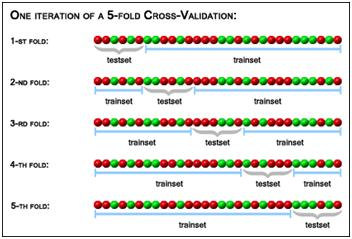

### Leave-one-out cross-validation

- Leave-one-out cross-validation is just the $n$-fold cross validation.

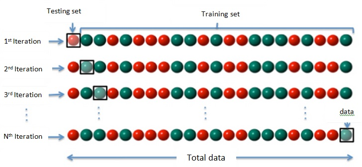

#### Leave-one-out cross-validation: definition

- Recall the steps towards the definition of *cross-validated residual* (in previous lecture).
  - Fit a linear regression line with all observation except $(y_i, {\mathbf x}_i)$, then predict the conditional mean of $y_i$ at ${\mathbf X}= {\mathbf x}_i$;
  - Call the predicted value
    $$\hat{Y}_{i(−i)},$$
  - The intermediate value
    $$Y_i - \hat{Y}_{i(−i)}$$
- The leave-one-out cross-validation score (LOOCV) is
  $$\mbox{LOOCV} = \frac{1}{n}\sum_{i=1}^n (Y_i - \hat{Y}_{i(−i)})^2.$$

#### Leave-one-out cross-validation: computation

- In evaluating linear models, leave-one-out cross-validation is indeed faster than $K-folds.
- It only requires to fit the model once (neither $K$ times nor $n$ times)
  $$\mbox{LOOCV} = \frac{1}{n}\sum_{i=1}^n \left(\frac{Y_i - \hat{Y}_{i}}{1- h_{ii}}\right)^2.$$

#### Leave-one-out cross-validation (LOOCV): approximation

By approximating $h_{ii}$ by its average $\bar{h} = \sum_{i=1}^n h_{ii} = (p+1)/n$ (and more), we get
$$\begin{align}
\mbox{LOOCV} &\approx \frac{1}{n}\sum_{i=1}^n ({Y_i - \hat{Y}_{i}})^2 + 2\bar{h}\frac{1}{n}\sum_{i=1}^n ({Y_i - \hat{Y}_{i}})^2 \\
&= \mbox{In-Sample MSE} + \frac{2\hat{\sigma}^2 (p+1)}{n}
\end{align}$$

## Mallows’ $C_p$

- Recall
  $$\mbox{"True MSE"} = E\left[ \mbox{In-Sample MSE} \right] + \frac{2}{n}\sigma^2(p+1).$$
- The Mallows $C_p$ statistic just substitutes in a feasible estimator of $σ^2$ into the optimism:

$$C_p = \frac{1}{n}\sum_{i=1}^n (Y_i - \hat{Y}_{i})^2 + \frac{2\hat{\sigma}^2 (p+1)}{n}.$$

- Typically, $C_p$ is computed for each model we consider, and $\hat\sigma^2$ is estimated only once, with the largest model (to ensure unbiased estimation).
- Note that $C_p$ is just an approximation of LOOCV score, thus is an approximation of Generalization MSE.

#### Alternative form of $C_p$.

- We can think of $C_p$ as follows:

$$C_p = \mbox{In-Sample MSE}+ \mbox{(penalty)}.$$

From one point of view, the penalty is just an estimate of the bias. From another point of view, it’s a cost we’re imposing on models for having extra parameters.

- Oftentimes, Mallows $C_p$ is altenatively defined as

$$C_p' = \frac{n}{\hat\sigma^2}C_p = n\frac{\mbox{In-Sample MSE}}{\hat\sigma^2} - n + 2p.$$

## These are equivalent, and we seek a model with smaller $C_p$.

## Information criteria

An information criterion is defined for each model, say $S$, and has the form:

$$\mbox{Information} = \mbox{In-Sample Performance} + \mbox{(Penalty)}.$$

- Two famous criateria:
  - Akaike information criterion (AIC)
  - Schwarz’s Bayesian Information Criterion (BIC)
- Both can be used for *any* model (not only linear models!)

### AIC

- Akaike information criterion (AIC) is

$$\mbox{AIC}(S) = -2 L_S + 2 dim(S).$$

- $L_S$ is the log-likelihood of the model $S$, evaluated at the maximum likelihood estimate.
- $dim(S)$ is the “dimension” of the model $S$, i.e. *the number of free parameters* in $S$.
- Larger model (model with many predictors): $-2L_S$ is smaller, but $dim(S)$ is larger.
- More parsimonious model (model with few predictors): $-2L_S$ is larger, but $dim(S)$ is smaller.

#### A toy data example

- Let’s take the famous `Boston` data (with $13$ predictors), and add 20 fake predictors.
- We will compare models $S_6$ through $S_{33}$, where the model $S_q$ means that we are including the first $q$ variables.
- In-Sample MSE should be smaller for larger $q$.
- Smallest LOOCV score or AIC should be from the model without the fake predictors.

```r
library(MASS)
library(tidyverse)
Bos_fake <- cbind(Boston[,c(14,1:13)], matrix(rnorm(nrow(Boston)*20),ncol = 20)  )
pmax <- ncol(Bos_fake) - 1

Infosave <- list()
for(p in 6:pmax){
  out <- lm(medv ~ . , data = Bos_fake[,c(1, 2:(p+1))])
  LOOCV <- mean(((Bos_fake$medv - fitted(out))/(1-hatvalues(out)))^2)
  Infosave[[p]] <- tibble(q = p,
                          AIC = AIC(out), BIC = BIC(out),
                          MSE = mean(out$residuals^2),
                          LOOCV = LOOCV)
}
Infosave <- bind_rows(Infosave)
```

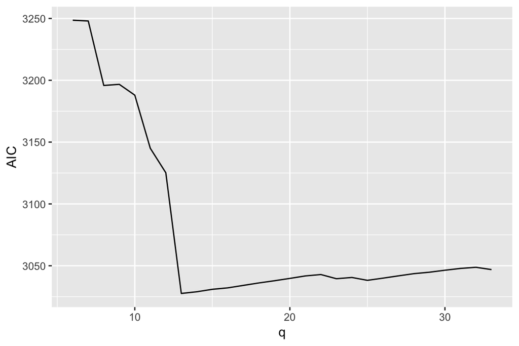

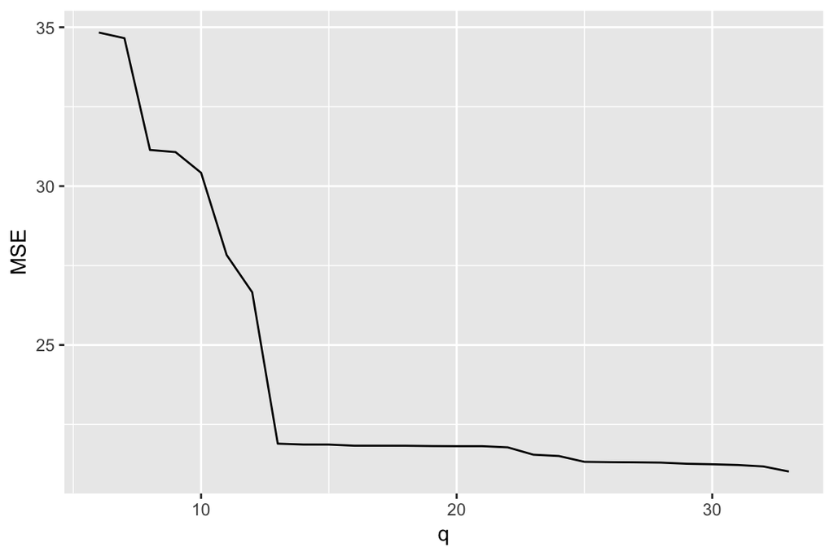

```r
Infosave %>% ggplot(aes(q,LOOCV)) + geom_line()
Infosave %>% ggplot(aes(q,AIC)) + geom_line()
Infosave %>% ggplot(aes(q,MSE)) + geom_line()
```

[output not shown]

- For the Gaussian linear model (i.e. we know the likelihood, and the LS estimate is the MLE) $Y = \beta_0 + \beta_1 X_1 +\cdots + \beta_p X_p + \epsilon$, $\epsilon \sim N(0,\sigma^2)$,

$$L_S = −n(1 + \log 2\pi) − n \log MSE,$$
and $dim(S) = p+2$.

#### What AIC does

- $AIC(S)/n$ is an unbiased estimate of the expected log-probability the estimated parameters for the model $S$ will give to a new data point which it hasn’t seen before, if the model is right.
- This is the natural counterpart of expected squared error for more general distributions than the Gaussian.
- Minimizing AIC $\approx$ Minimizing Generalization Error rate
- The model chosen by AIC may be a larger model than truth, as long as the chosen model predicts better than the truth (given data).

### BIC

- Schwarz’s Bayesian Information Criterion (BIC) is

$$\mbox{BIC}(S) = -2 L_S + \log(n) dim(S),$$
where $n$ is the sample size.

- Compare BIC with AIC; the penalty in BIC $\log(n)dim(S)$ is stronger than $2dim(S)$ of AIC, thus BIC tends to choose smaller models.
- In fact, As $n \to \infty$, if the true model is among those BIC can select among, BIC will tend to pick the true model.

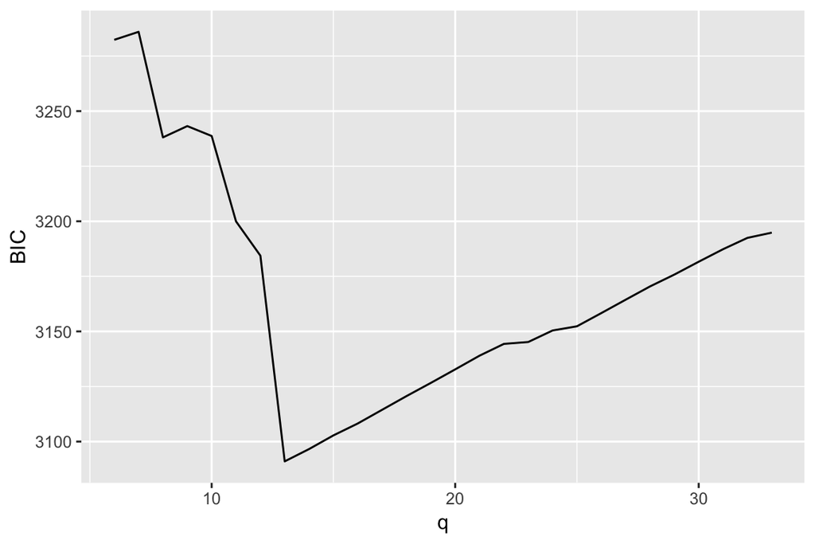

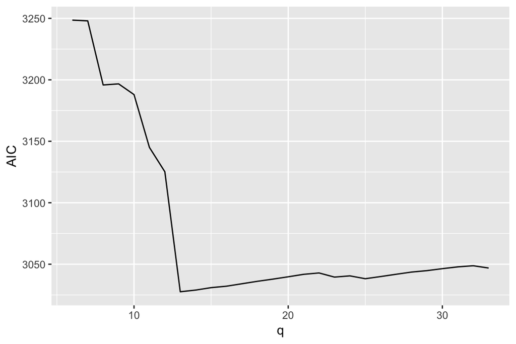

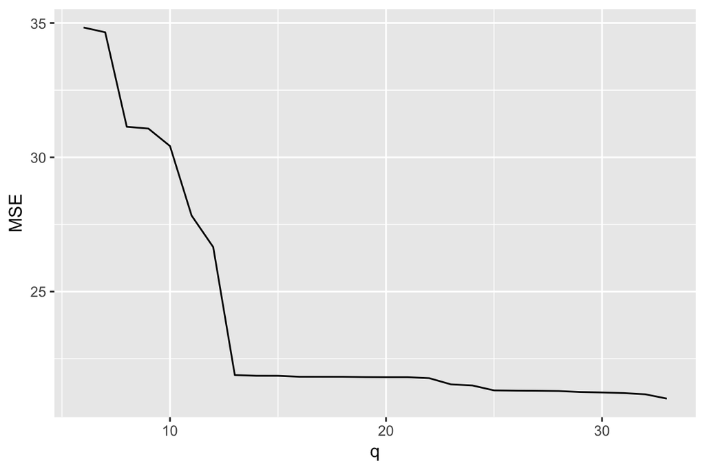

```r
Infosave %>% ggplot(aes(q,BIC)) + geom_line()
Infosave %>% ggplot(aes(q,AIC)) + geom_line()
Infosave %>% ggplot(aes(q,MSE)) + geom_line()
```

#### Comparison with K-fold CV

We should compare the LOOCV $\approx C_p \approx AIC \approx BIC$ with a K-fold cross-validation score. A K-fold CV can be manually implemented, but there are many options in R. Two popular options:

- `cv.glm()` in `boot` package
- `cv.glmnet()` in `glmnet` package; will revisit this later.

Let’s forget about “g” in `glm` for now. It means “generalized”, and a special case is simply `lm`.

#### Cross-validation using `cv.glm()`

- Fit a linear model using `glm()`

```r
out <- glm(medv ~ crim + zn , data = Boston) # this just fits a linear model
out$coefficients
```

```
## (Intercept)        crim          zn
##  22.4856281  -0.3520783   0.1161091
```

- Compare the coefficient estimates from those of `lm()`

```r
lm(medv ~ crim + zn , data = Boston)$coefficients
```

```
## (Intercept)        crim          zn
##  22.4856281  -0.3520783   0.1161091
```

To compute the $K$-fold CV score, use `cv.glm()` in `boot` package.

```r
library(boot)
cv.glm(Boston, out, K = 5)$delta[1]
```

```
## [1] 65.35782
```

- In fact, we can compute LOOCV score as well.

```r
out <- glm(medv ~ crim + zn , data = Boston)
cv.glm(Boston, out)$delta[1] # By not specifying K, we set K = n (i.e. Leave-one-out)
```

```
## [1] 65.84389
```

```r
mean(((Boston$medv - fitted(out))/(1-hatvalues(out)))^2)
```

```
## [1] 65.84389
```

- Using `cv.glm()` in computation for LOOCV score is not advisable. Why?

Let’s compare 5-fold CV scores with LOOCV scores

```r
Infosave <- list()
for(p in 6:pmax){
  out <- glm(medv ~ . , data = Bos_fake[,c(1, 2:(p+1))])
  LOOCV <- mean(((Bos_fake$medv - fitted(out))/(1-hatvalues(out)))^2)
  KCV <- cv.glm(Bos_fake, out, K = 5)$delta[2]
  Infosave[[p]] <- tibble(q = p,
                          KCV = KCV,
                          LOOCV = LOOCV)
}
Infosave <- bind_rows(Infosave)
```

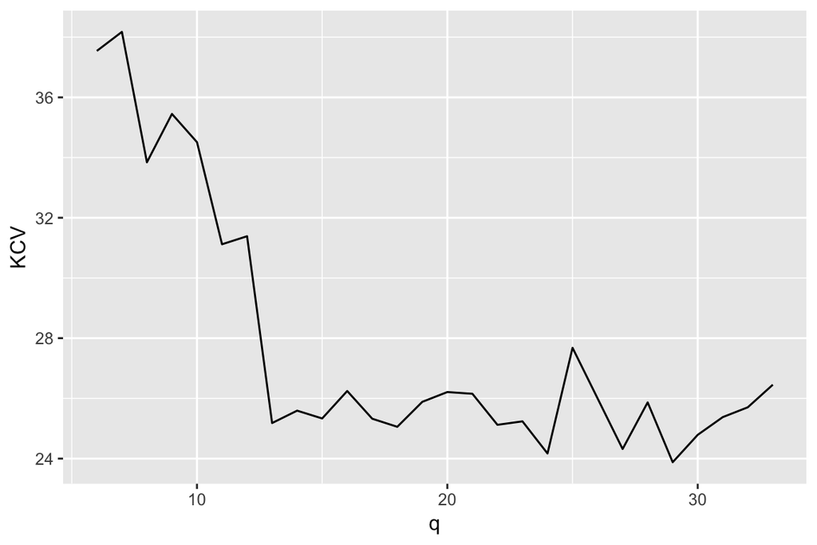

```r
Infosave %>% ggplot(aes(q,LOOCV)) + geom_line()
Infosave %>% ggplot(aes(q,KCV)) + geom_line()
```

[output not shown]

What has gone wrong?

1. Why is it flutuating?
   - Randomness in folding
2. Remedies?
3. Why use 5-fold over LOOCV?